Bennett Widyolar  
ES 207 - HW #7  
4/1/2016

# Homework Assignment 7

## Objective

The objective of this study is to determine the percentage of years it floods more than 100 days (floods defined as discharges >= 800 cubic feet per second) along the Cosumnes River, to assist the California Department of Water Resources in determining whether or not setback levee construction is a good use of Prop. 1 funds for the purpose of groundwater recharge.

## Methods

In this study, we will analyze discharge measurements along the Cosumnes River to determine the number of flood events per year. The percentage of years having greater than 100 flood days will be reported back to the DWR.

## Data

The data used has been collected by the USGS since 1907 for the following site: Site #: 11335000 Site Name: Michigan Bar Sensor: Discharge, cubic feet per second (mean)

It is available at the following url: http://waterdata.usgs.gov/nwis/dv?cb_00060=on&format=rdb&site_no=11335000&referred_module=sw&period=&begin_date=1907-10-01&end_date=2015-09-30

## Code

The code for this project is as follows:

```r
#CLEAR VARIABLES
rm(list=ls())

site='11335000'
sensor='00060'
start='1907-10-01'
end='2015-09-30'

data <- read.table(paste("http://waterdata.usgs.gov/nwis/dv?cb_",sensor,"=on&format=rdb&site_no=", site,"&referred_module=sw&period=&begin_date=",start,"&end_date=", end, sep=""),
                   header=T, sep="", quote="'", skip=0, colClasses = c("factor", "factor", "factor", "factor", "factor"))
print('DONE')

#REMOVE JUNK DATA FROM FIRST ROW
data = droplevels(data[-1,])
#RENAME LAST TWO COLUMNS
colnames(data)[4:5]= c("discharge_cfs","dat_qvalue")

data$datetime = as.POSIXct(data$datetime, "America/Los_Angeles")
data$discharge_cfs = as.double(as.character(data$discharge_cfs))

data$discharge_afd = data$discharge_cfs*1.98347
#NOTE POSSIBLE OUTLIER - 122,200 AF/Day?

#WATER YEAR
data$year = as.numeric(substr(data$datetime,1,4))
data$month = as.numeric(substr(data$datetime,6,7))
data$day = as.numeric(substr(data$datetime,9,11))
data$wy = ifelse(data$month > 9, data$year +1, data$year)
data$wym = ifelse(data$month > 9, data$month - 9, data$month + 3)

#REMOVE LEAP YEAR
data <- data[!(data$month ==2 & data$day == 29),]

#TOTAL DISCHARGE BY MONTH
data.mo.afd.sum = ts(as.vector(tapply(data$discharge_afd,list(data$wym,data$wy),sum)),frequency=12)
data.mo.afd.mean = ts(as.vector(tapply(data$discharge_afd,list(data$wym,data$wy),mean)),frequency=12)
data.mo.afd.max = ts(as.vector(tapply(data$discharge_afd,list(data$wym,data$wy),max)),frequency=12)
data.mo.cfs.mean = ts(as.vector(tapply(data$discharge_cfs,list(data$wym,data$wy),mean)),frequency=12)
data.mo.cfs.max = ts(as.vector(tapply(data$discharge_cfs,list(data$wym,data$wy),max)),frequency=12)

data.yr.afd.sum = ts(as.vector(tapply(data$discharge_afd,list(data$wy),sum)),frequency=1)
data.yr.afd.mean = ts(as.vector(tapply(data$discharge_afd,list(data$wy),mean)),frequency=1)

#DRIEST YEAR
index_min = which.min(data.yr.afd.sum)
plot(data.mo.afd.mean[(index_min*12+1):(index_min*12+12)], type="o")
#WETTEST YEAR
index_max = which.max(data.yr.afd.sum)
plot(data.mo.afd.mean[(index_max*12+1):(index_max*12+12)], type="o")
#HIGHEST DAILY AVERAGE DISCHARGE
index_discharge = which.max(data.yr.afd.mean)
plot(data.mo.afd.mean[(index_discharge*12+1):(index_discharge*12+12)], type="o")

plot(stl(data.mo.afd.mean,s.window="periodic"))
plot(acf(data.mo.afd.mean))

#FLOODS
plot(data$discharge_cfs)
threshold = 800
abline(h=threshold, col="red")

data$flood <- data$discharge_cfs >= threshold
data.yr.flood.sum <- ts(as.vector(tapply(data$flood, list(data$wy),sum)), start=1907)
print(sum(data.yr.flood.sum >= 100)/length(data.yr.flood.sum))
```

## Results

```
## [1] "DONE"
```

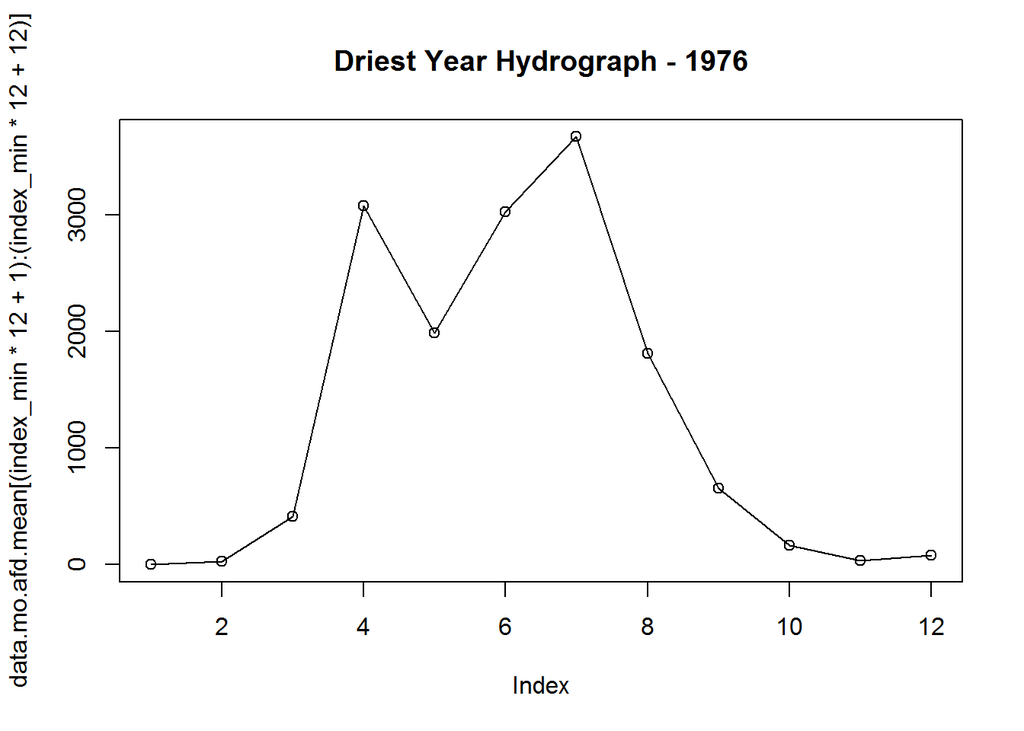

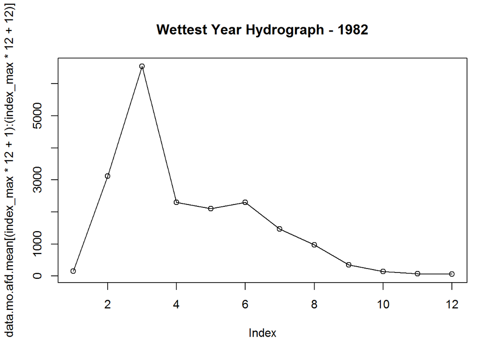

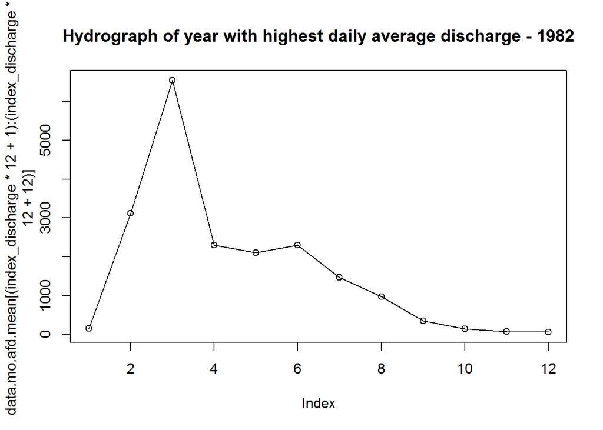

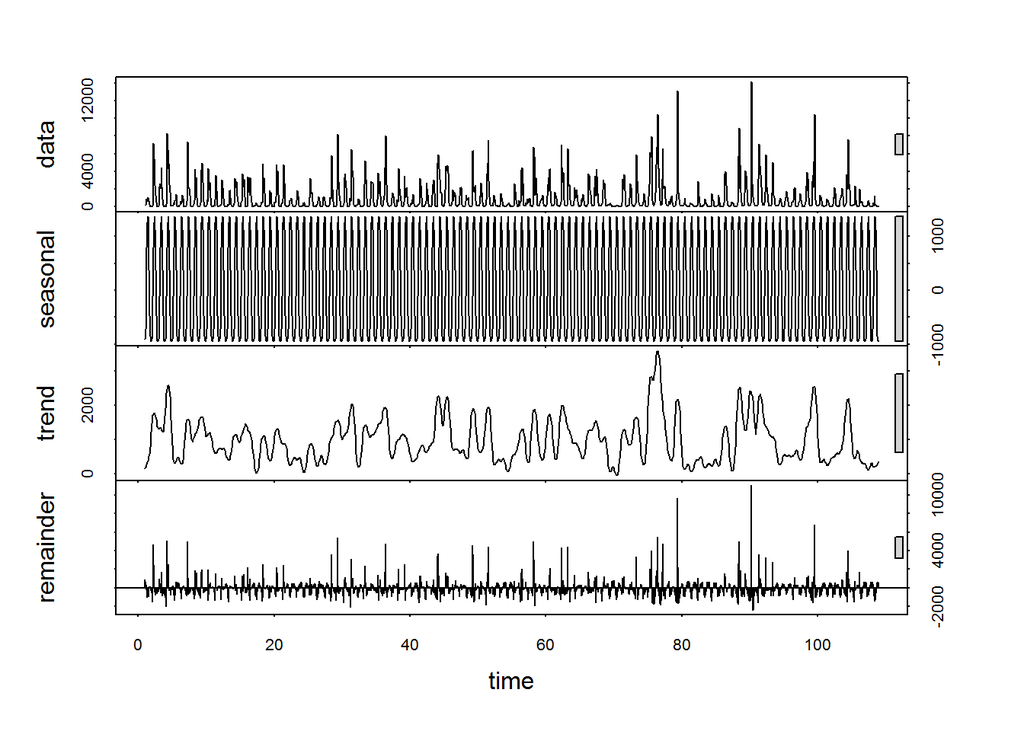

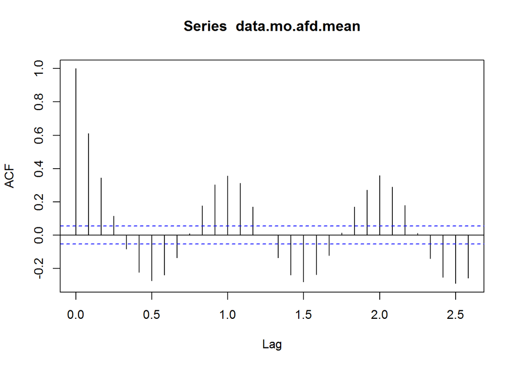

Flood analysis is performed below. The hydrograph (Daily) since 1907 is plotted along with the drawn threshold of 800 cfs at which a day is counted as a flood event.

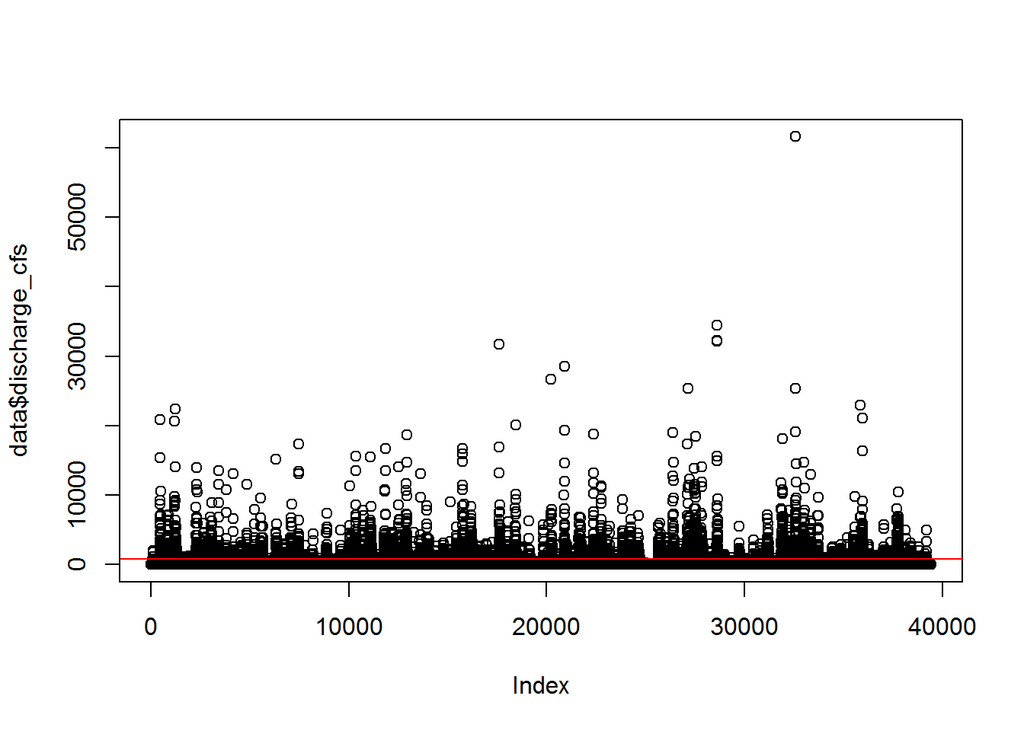

The percentage of years from 1907-2015 with more than 100 flood events is evaluated below.

```
## [1] 0.3055556
```

## Limitations

See header of data file: http://waterdata.usgs.gov/nwis/dv?cb_00060=on&format=rdb&site_no=11335000&referred_module=sw&period=&begin_date=1907-10-01&end_date=2015-09-30